# Challenge 3: GEDI AGBD data

**GEDI L4B AGBD biomass data**

The [GEDI L4B AGB product](https://daac.ornl.gov/GEDI/guides/GEDI_L4B_Gridded_Biomass.html) provides km x 1 km estimates of mean aboveground biomass density (AGBD) based on observations from 2019-04-18 to 2021-08-04. Each waveform is converted to an AGBD prediction based on estimated forest height.

The GEDI data has a number of sources of uncertainty, including the sampling of the 1km area (as opposed to making wall-to-wall observations) and the modelling approach of the biomass values.

**Exploring the GEDI data**

Let’s start by loading up the libraries we will need to import and interrogate the GEDI biomass data. It is in [GeoTIFF](https://www.ogc.org/standard/geotiff/) format, a file format used in the geospatial and earth science communities for geographic image data. GDAL (the Geospatial Data Abstraction Library) is a major software library for reading/writing raster & vector geospatial data, and forms the basis of most software for processing such data.

Aside:

**Raster** data is any pixelated (or gridded) data where each pixel is associated with a specific geographical location. The value of a pixel can be continuous (e.g. elevation) or categorical (e.g. land use). A geospatial raster differs only a digital photo in that it is accompanied by spatial information that connects the data to a particular location - the spatial extent, cell size, coordinate reference system (CRS), etc. An example of a continuous raster would be maps of tree height derived from LiDAR data, or precipitation maps.

**Vector** data structures represent specific features on the Earth’s surface, and assign attributes to those features. They are composed of discrete x,y geometric locations or vertices that define the shape of the spatial object. The organisation of the vertices determines the type of vector that we are working with - these are points (defined by a single x, y coordinate), lines (at least 2 points that are connected) or polygons (3 or more points that are connected and closed).

**How to read in GEDI raster data**

We can explore the data in one of a couple of ways in R. We can use the `raster` package to read and manipulate raster data. The `rgdal` package provides bindings to [GDAL](https://gdal.org/index.html) and access to projection/transformation operations from the ‘PROJ.4’ library.

```r
# Install necessary packages
if (!require(raster)) install.packages('raster')
if (!require(rgdal)) install.packages('rgdal')
```

[output not shown]

```r
# Load necessary libraries
library(raster)
library(rgdal)

# Read the raster data
# Replace 'path_to_your_raster_file' with the actual path to your raster file
raster_path= "/Users/aoibheannbrady/Downloads/GEDI_L4B_Gridded_Biomass_V2_1_2299/data/GEDI04_B_MW019MW223_02_002_02_R01000M_MU.tif"
raster_data = raster(raster_path)

# Print the raster data to check its structure
print(raster_data)
```

```
class      : RasterLayer
dimensions : 14616, 34704, 507233664  (nrow, ncol, ncell)
resolution : 1000.895, 1000.895  (x, y)
extent     : -17367530, 17367530, -7314541, 7314541  (xmin, xmax, ymin, ymax)
crs        : +proj=cea +lat_ts=30 +lon_0=0 +x_0=0 +y_0=0 +datum=WGS84 +units=m +no_defs
source     : GEDI04_B_MW019MW223_02_002_02_R01000M_MU.tif
names      : GEDI04_B_MW019MW223_02_002_02_R01000M_MU
```

Note that the extent is in Easting/Northing coordinates rather than latitude and longitude. We’ll plot the global raster below.

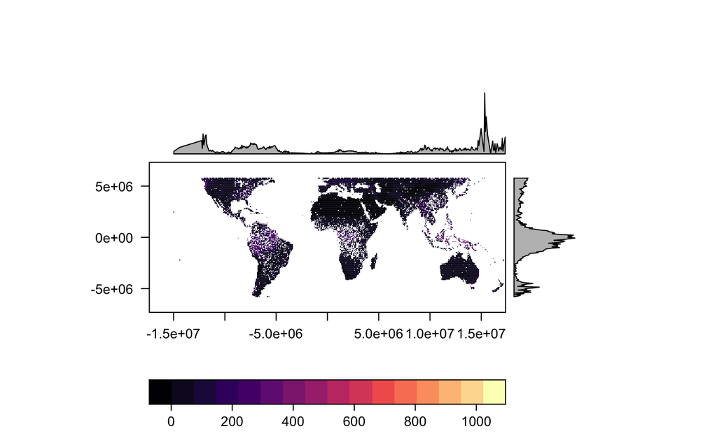

```r
if (!require(rasterVis)) install.packages('rasterVis')
library(rasterVis)
# Plot the raster data
levelplot(raster_data)
```

As mentioned, the data in Easting & Northing coordinates [EPSG 6933](https://spatialreference.org/ref/epsg/6933) so we’ll want to reproject this now.

```r
# Define the new CRS
new_crs = "+init=epsg:4326"  # WGS 84

# Reproject the raster data
reprojected = projectRaster(raster_data, crs = new_crs)
```

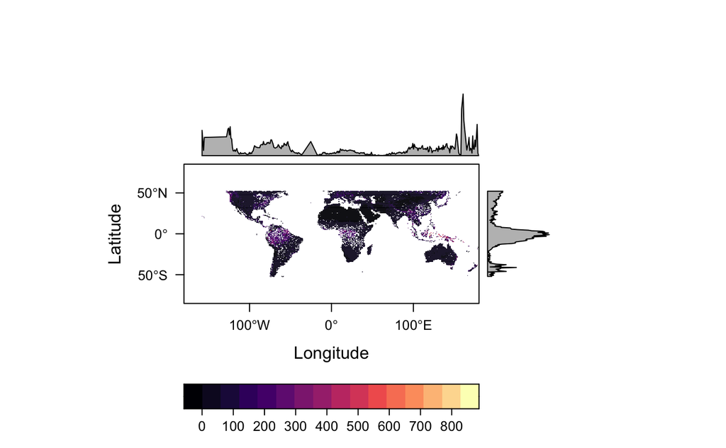

```r
levelplot(reprojected)
```

Let’s now plot a histogram of the data. We get the values from the reprojected raster, then plot.

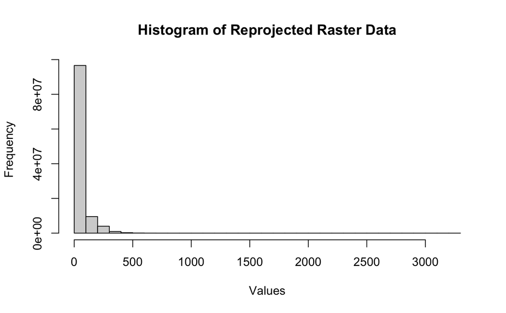

```r
values = getValues(reprojected)
hist(values, main = "Histogram of Reprojected Raster Data", xlab = "Values", ylab = "Frequency")
```

Let’s check what the nodata value is.

```r
NAvalue(reprojected)
```

```
[1] -3.4e+38
```

We’ll now filter that out.

```r
reprojected[reprojected <-3e+38] <- NA
```

Now let’s plot it once more to see if the nodata values are gone.

```r
levelplot(reprojected)
```

[output not shown]

**Vector data & clipping to boundaries**

The GEDI biomass data layer above is a global layer, which can be hard/slow to visualise in terms of compute. In any case, for our challenge we are interested in the legal Amazon region, so we can clip the dataset to this boundary. This is in another file format, a shapefile, which is a polygon, multipolygon or series of polygons which represent some area. As mentioned, a polygon is a vector data format, which we can read in using `readOGR` which is from the `rgdal` package.

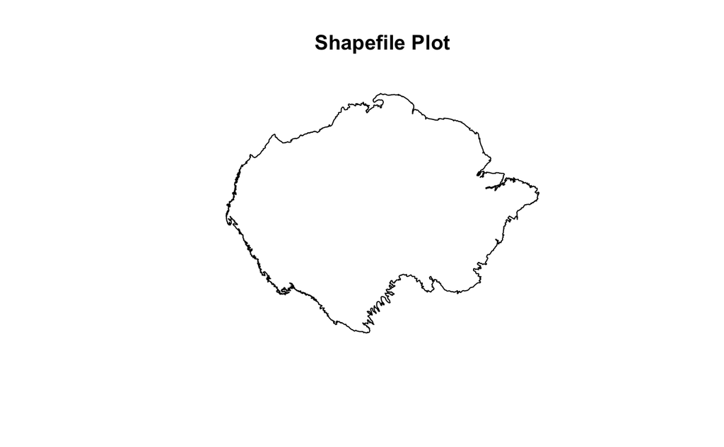

```r
shapefile_path = '/Users/aoibheannbrady/Downloads/Amazon_forest_boundary.gpkg'  # Replace with your shapefile path

# Read the shapefile
gdf = readOGR(shapefile_path)
plot(gdf, main = "Shapefile Plot")
```

```r
NA
NA
```

Now let’s clip the raster using the shapefile. We can do this using the `mask` function in the `raster` package to do this.

```r
clipped = mask(reprojected, gdf)
```

We should now have data only in the Amazon, let’s check!

```r
levelplot(clipped)
```

[output not shown]

Let’s check that all our NA values are gone.

```r
values = getValues(clipped)
hist(values, main = "Histogram of Reprojected Raster Data", xlab = "Values", ylab = "Frequency")
```

[output not shown]